# Project

### 4.2-11-a

Cook’s distance

After identifying cases that are outlying with respect to their Y values and or with their X values, the next step is to find whether or not these outlying cases are influential. We shall consider a case to be influential if its exclusion causes major changes in the fitted regression function

Cook’s distance measure considers the influence of the ith case on all n fitted values. Cook’s distance measure, denoted by Di , is an aggregate influence measure, showing the effect of the i th case on all n fitted values

Cook’s distance greater than 4/n, where n is total number of observations in dataset. Then it is considered as outlier.

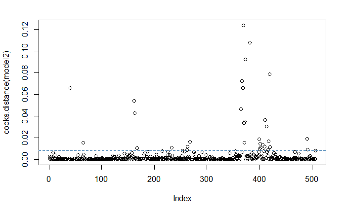

```r
n<-nrow(data1)
plot(cooks.distance(model2))
abline(h = 4/n, lty = 2, col = "steelblue")
```

```r
cooksD <- cooks.distance(model2)
```

Now, we remove all outliers based on Cook’s distance threshold as said above. Now we fit the model using the dataset with outlying observations removed.

Adjusted R square improved from 0.7743 to 0.8469. Residual standard error decreased from 0.315 to 0.2283.

```r
influential_obs <- as.numeric(names(cooksD)[(cooksD > (4/n))])
print(influential_obs)
```

```
 [1]  41  65 162 163 167 233 254 262 263 268 365 366 368 369 370 371 372 373 381 399 400 401 402
[24] 406 410 411 413 416 417 419 420 490 491 506
```

```r
outliers_removed <- trans_data1[-influential_obs, ]

model3=lm(formula = MEDV ~ ., data = outliers_removed)
summary(model3)
```

```
Call:
lm(formula = MEDV ~ ., data = outliers_removed)

Residuals:
     Min       1Q   Median       3Q      Max
-0.75124 -0.12860 -0.01593  0.12369  0.99120

Coefficients:
              Estimate Std. Error t value Pr(>|t|)
(Intercept)  3.2196814  0.2637953  12.205  < 2e-16 ***
CRIM        -0.0195262  0.0029752  -6.563 1.43e-10 ***
ZN          -0.0003458  0.0006764  -0.511  0.60949
INDUS       -0.0048341  0.0028029  -1.725  0.08526 .
CHAS         0.1058293  0.0441620   2.396  0.01696 *
NOX         -0.9008653  0.1905821  -4.727 3.04e-06 ***
RM           0.2938727  0.0263769  11.141  < 2e-16 ***
AGE         -0.0020784  0.0006715  -3.095  0.00209 **
DIS         -0.0703592  0.0101950  -6.901 1.72e-11 ***
RAD          0.0042491  0.0023223   1.830  0.06794 .
PTRATIO     -0.0527304  0.0064843  -8.132 3.97e-15 ***
B            0.0009373  0.0001427   6.570 1.37e-10 ***
LSTAT        3.0433556  0.2961081  10.278  < 2e-16 ***
---
Signif. codes:  0 ‘***’ 0.001 ‘**’ 0.01 ‘*’ 0.05 ‘.’ 0.1 ‘ ’ 1

Residual standard error: 0.2283 on 459 degrees of freedom
Multiple R-squared:  0.8508,    Adjusted R-squared:  0.8469
F-statistic: 218.2 on 12 and 459 DF,  p-value: < 2.2e-16
```

```r
anova(model3)
```

```
Analysis of Variance Table

Response: MEDV
           Df Sum Sq Mean Sq  F value    Pr(>F)
CRIM        1 49.145  49.145 942.6924 < 2.2e-16 ***
ZN          1 14.035  14.035 269.2205 < 2.2e-16 ***
INDUS       1 10.438  10.438 200.2176 < 2.2e-16 ***
CHAS        1  1.927   1.927  36.9661 2.532e-09 ***
NOX         1  0.496   0.496   9.5231 0.0021517 **
RM          1 39.897  39.897 765.3018 < 2.2e-16 ***
AGE         1  2.221   2.221  42.5997 1.781e-10 ***
DIS         1  4.910   4.910  94.1909 < 2.2e-16 ***
RAD         1  0.688   0.688  13.1945 0.0003124 ***
PTRATIO     1  3.865   3.865  74.1466 < 2.2e-16 ***
B           1  3.369   3.369  64.6268 7.747e-15 ***
LSTAT       1  5.507   5.507 105.6343 < 2.2e-16 ***
Residuals 459 23.929   0.052
---
Signif. codes:  0 ‘***’ 0.001 ‘**’ 0.01 ‘*’ 0.05 ‘.’ 0.1 ‘ ’ 1
```

Analyzing following mentioned plot before and after removing outliers, plots are residuals vs fitted, residuals boxplot,qq plot and histogram

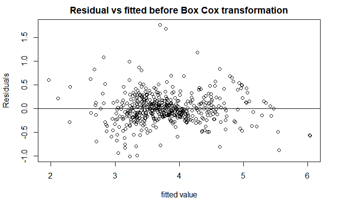

```r
residuals = resid(model2)
plot(fitted(model2), residuals,ylab="Residuals",xlab="fitted value", main="Residual vs fitted before Box Cox transformation")
abline(0,0)
```

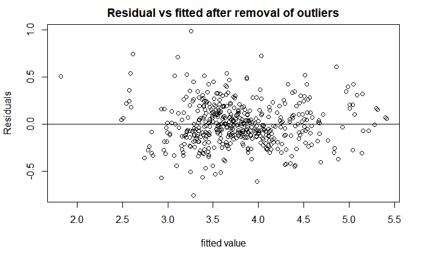

```r
residuals = resid(model3)
plot(fitted(model3), residuals,ylab="Residuals",xlab="fitted value", main="Residual vs fitted after removal of outliers")
abline(0,0)
```

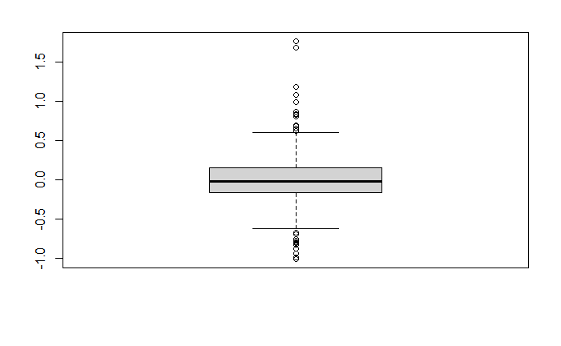

```r
residuals = resid(model2)
boxplot(residuals)
```

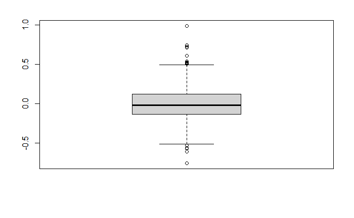

```r
residuals = resid(model3)
boxplot(residuals)
```

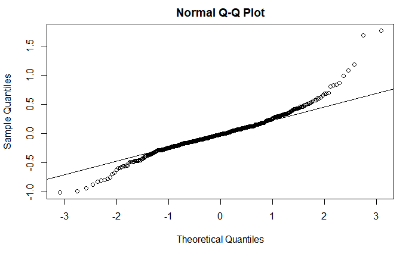

```r
residuals = resid(model2)
qqplot<-(qqnorm(residuals))
qqline(residuals)
```

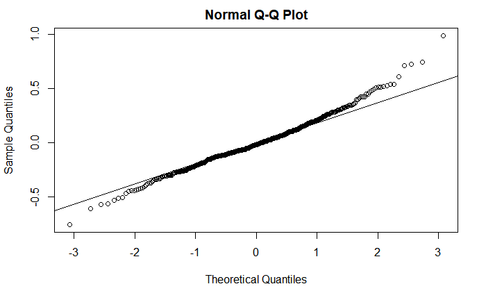

```r
residuals = resid(model3)
qqplot<-(qqnorm(residuals))
qqline(residuals)
```

```r
NA
NA
```

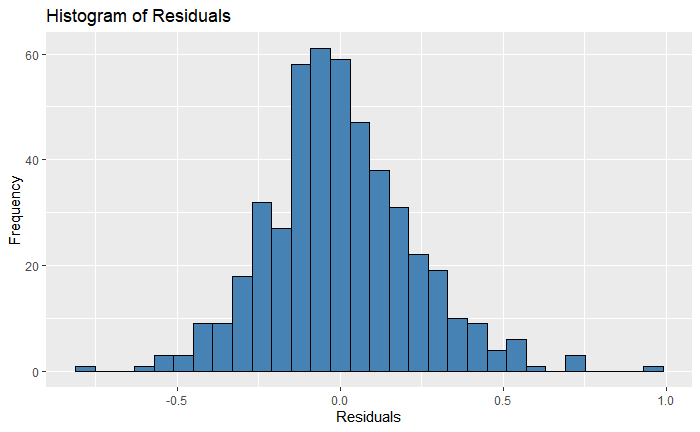

```r
#summary(model3)
library(ggplot2)

#create histogram of residuals
ggplot(data = outliers_removed, aes(x = model3$residuals)) +
    geom_histogram(fill = 'steelblue', color = 'black') +
    labs(title = 'Histogram of Residuals', x = 'Residuals', y = 'Frequency')
```

```r
qt(p=.05, df=511-14, lower.tail=TRUE)
```

```
[1] -1.647925
```

```r
nrow(outliers_removed)
```

```
[1] 472
```

### 4.2-11-b

DFBETAS

One way to calculate the influence of observations is by using a metric known as DFBETAS, which tells us the standardized effect on each coefficient of deleting each individual observation. This metric gives us an idea of how influential each observation is on each coefficient estimate in a given regression model.

```r
dfbetas <- as.data.frame(dfbetas(model2))
dfbetas
```

|  | (Intercept) | CRIM | ZN | INDUS | CHAS | NOX | RM | AGE | DIS | RAD | PTRATIO | B | LSTAT |
| --- | --- | --- | --- | --- | --- | --- | --- | --- | --- | --- | --- | --- | --- |
| 1 | -3.915073e-02 | -9.963323e-03 | 2.292774e-02 | 1.023548e-01 | 3.804235e-02 | -5.070166e-02 | 5.860917e-02 | -3.737350e-02 | 1.238470e-02 | 1.812080e-02 | 4.687212e-02 | 3.035692e-03 | -8.053373e-02 |
| 2 | -2.994726e-03 | -3.608482e-03 | 1.971090e-02 | -1.340914e-04 | 5.575412e-03 | 1.207093e-02 | -2.168355e-03 | -2.385971e-02 | -1.737349e-02 | 4.354324e-03 | 9.038095e-03 | -7.790908e-04 | -6.576059e-04 |
| 3 | -4.214062e-03 | 3.172618e-03 | -1.272552e-02 | 2.249185e-03 | -4.350896e-03 | -7.527859e-05 | 2.530669e-03 | 5.693040e-03 | 8.592241e-03 | -3.780070e-03 | 3.085411e-04 | -1.106163e-03 | 1.321089e-02 |
| 4 | 2.868016e-02 | -1.571687e-02 | 9.093067e-02 | 3.525814e-02 | 2.264449e-02 | -3.972413e-02 | 3.969982e-02 | -3.147742e-02 | -6.616649e-02 | 9.469363e-03 | -3.065312e-02 | 1.499077e-02 | -1.452600e-01 |
| 5 | -7.327778e-02 | 2.733834e-02 | -1.137357e-01 | -5.004414e-02 | -1.776516e-02 | 4.262450e-02 | 5.437766e-02 | 2.560922e-02 | 9.316036e-02 | -2.202425e-02 | 3.338130e-02 | -1.393995e-03 | 3.843602e-02 |
| 6 | -4.499271e-03 | 4.186572e-03 | -3.019179e-02 | -1.871024e-02 | -4.917232e-03 | 7.921532e-03 | -1.160111e-02 | 1.645615e-02 | 2.483054e-02 | -1.652176e-03 | 5.309286e-03 | -3.291060e-03 | 2.666375e-02 |
| 7 | 1.364345e-02 | -9.353751e-04 | -1.344773e-02 | 1.851997e-03 | -5.058442e-03 | -2.829888e-03 | -5.739688e-03 | 8.800656e-03 | 1.737938e-02 | 8.163024e-03 | -2.763806e-02 | 4.427843e-03 | -5.817141e-03 |
| 8 | 4.406833e-02 | -6.050693e-03 | -7.041373e-02 | 1.504060e-02 | -3.060542e-02 | -4.510785e-02 | -4.984154e-03 | 1.747785e-01 | 1.602424e-01 | 4.954970e-02 | -1.601598e-01 | 2.628853e-02 | -4.458503e-02 |
| 9 | -1.723327e-02 | 2.963170e-03 | 1.283426e-02 | -1.301088e-04 | 5.167244e-03 | 1.109748e-02 | 1.397363e-02 | -3.869089e-02 | -3.151366e-02 | -1.169667e-02 | 3.368264e-02 | -2.458228e-03 | 4.234903e-03 |
| 10 | -2.858887e-03 | 1.365169e-04 | 5.914861e-03 | -1.367967e-03 | 1.752168e-03 | 1.362199e-03 | 1.484871e-03 | -9.458867e-03 | -1.198272e-02 | -3.058995e-03 | 1.028084e-02 | -1.029383e-03 | 1.757591e-03 |

[output cut: 496 more lines]

As a guideline for identifying influential cases, we consider a case influential if the absolute value of DFBETAS exceeds 1 for small to medium data sets and 2/ In for large data sets.

```r
thresh<-2/sqrt(nrow(trans_data1))
print(thresh)
```

```
[1] 0.08891084
```

Based on the above calculated thresholds below are the plots to observe DFBETAS of each predictor variable.

```r
par(mfrow = c(2,2))
plot(dfbetas$CRIM, type='h')
abline(h = thresh, lty = 2)
```

```r
abline(h = -thresh, lty = 2)

plot(dfbetas$ZN, type='h')
```

```r
abline(h = thresh, lty = 2)
abline(h = -thresh, lty = 2)
```

```r
plot(dfbetas$INDUS, type='h')
abline(h = thresh, lty = 2)
```

```r
abline(h = -thresh, lty = 2)

plot(dfbetas$CHAS, type='h')
```

```r
abline(h = thresh, lty = 2)
abline(h = -thresh, lty = 2)
```

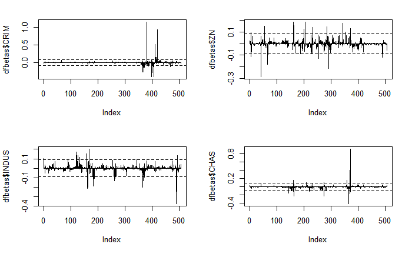

```r
par(mfrow = c(2,2))
```

```r
plot(dfbetas$NOX, type='h')
abline(h = thresh, lty = 2)
```

```r
abline(h = -thresh, lty = 2)

plot(dfbetas$RM, type='h')
```

```r
abline(h = thresh, lty = 2)
abline(h = -thresh, lty = 2)
```

```r
plot(dfbetas$AGE, type='h')
abline(h = thresh, lty = 2)
```

```r
abline(h = -thresh, lty = 2)

plot(dfbetas$DIS, type='h')
```

```r
abline(h = thresh, lty = 2)
abline(h = -thresh, lty = 2)
```

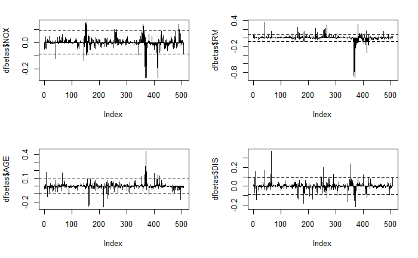

```r
par(mfrow = c(2,2))
```

```r
plot(dfbetas$RAD, type='h')
abline(h = thresh, lty = 2)
```

```r
abline(h = -thresh, lty = 2)

# plot(dfbetas$TAX, type='h')
# abline(h = thresh, lty = 2)
# abline(h = -thresh, lty = 2)

plot(dfbetas$PTRATIO, type='h')
```

```r
abline(h = thresh, lty = 2)
abline(h = -thresh, lty = 2)
```

```r
plot(dfbetas$B, type='h')
abline(h = thresh, lty = 2)
```

```r
abline(h = -thresh, lty = 2)

plot(dfbetas$LSTAT, type='h')
```

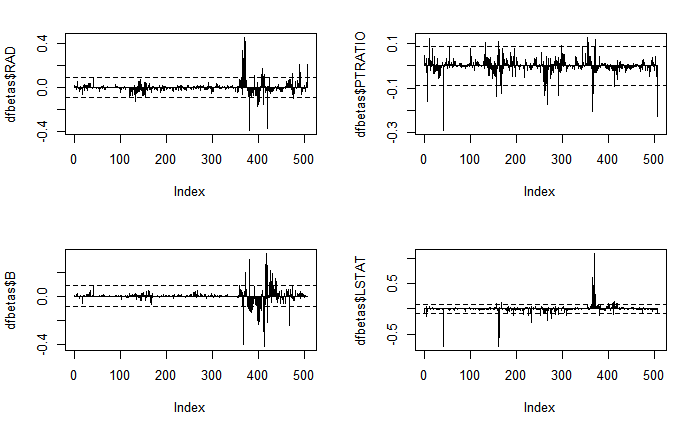

```r
abline(h = thresh, lty = 2)
abline(h = -thresh, lty = 2)
```

```r
outliers_wrt_CRIM<-leverages[dfbetas$CRIM>thresh]
cat("Influentials observations with respective to CRIM=",length(outliers_wrt_CRIM),"\n")
```

```
Influentials observations with respective to CRIM= 5
```

```r
outliers_wrt_ZN<-leverages[dfbetas$ZN>thresh]
cat("Influentials observations with respective to ZN=",length(outliers_wrt_ZN),"\n")
```

```
Influentials observations with respective to ZN= 13
```

```r
outliers_wrt_INDUS<-leverages[dfbetas$INDUS>thresh]
cat("Influentials observations with respective to INDUS=",length(outliers_wrt_INDUS),"\n")
```

```
Influentials observations with respective to INDUS= 10
```

```r
outliers_wrt_CHAS<-leverages[dfbetas$CHAS>thresh]
cat("Influentials observations with respective to CHAS=",length(outliers_wrt_CHAS),"\n")
```

```
Influentials observations with respective to CHAS= 9
```

```r
outliers_wrt_NOX<-leverages[dfbetas$NOX>thresh]
cat("Influentials observations with respective to NOX=",length(outliers_wrt_NOX),"\n")
```

```
Influentials observations with respective to NOX= 12
```

```r
outliers_wrt_RM<-leverages[dfbetas$RM>thresh]
cat("Influentials observations with respective to RM=",length(outliers_wrt_RM),"\n")
```

```
Influentials observations with respective to RM= 21
```

```r
outliers_wrt_AGE<-leverages[dfbetas$AGE>thresh]
cat("Influentials observations with respective to AGE=",length(outliers_wrt_AGE),"\n")
```

```
Influentials observations with respective to AGE= 15
```

```r
outliers_wrt_DIS<-leverages[dfbetas$DIS>thresh]
cat("Influentials observations with respective to DIS=",length(outliers_wrt_DIS),"\n")
```

```
Influentials observations with respective to DIS= 14
```

```r
outliers_wrt_RAD<-leverages[dfbetas$RAD>thresh]
cat("Influentials observations with respective to RAD=",length(outliers_wrt_RAD),"\n")
```

```
Influentials observations with respective to RAD= 17
```

```r
outliers_wrt_PTRATIO<-leverages[dfbetas$PTRATIO>thresh]
cat("Influentials observations with respective to PTRATIO=",length(outliers_wrt_PTRATIO),"\n")
```

```
Influentials observations with respective to PTRATIO= 7
```

```r
outliers_wrt_B<-leverages[dfbetas$B>thresh]
cat("Influentials observations with respective to B=",length(outliers_wrt_B),"\n")
```

```
Influentials observations with respective to B= 13
```

```r
outliers_wrt_LSTAT<-leverages[dfbetas$LSTAT>thresh]
cat("Influentials observations with respective to LSTAT=",length(outliers_wrt_LSTAT),"\n")
```

```
Influentials observations with respective to LSTAT= 18
```

DFBETAS for data with outliers removed based on COOK’S distance.

```r
dfbetas <- as.data.frame(dfbetas(model3))
dfbetas
```

|  | (Intercept) | CRIM | ZN | INDUS | CHAS | NOX | RM | AGE | DIS | RAD | PTRATIO | B | LSTAT |
| --- | --- | --- | --- | --- | --- | --- | --- | --- | --- | --- | --- | --- | --- |
| 1 | -5.764956e-02 | -4.680135e-03 | 3.751112e-02 | 1.159816e-01 | 4.971267e-02 | -5.626875e-02 | 9.269193e-02 | -7.389550e-02 | 1.187960e-02 | 9.902516e-03 | 6.348422e-02 | 6.272873e-03 | -1.333206e-01 |
| 2 | -9.291068e-04 | -8.534532e-03 | 2.591064e-02 | -2.193964e-03 | 7.549611e-03 | 1.401531e-02 | -4.912716e-03 | -2.836296e-02 | -2.323666e-02 | 8.602198e-03 | 1.181638e-02 | -1.619051e-03 | -1.425895e-03 |
| 3 | -9.039564e-03 | 8.971165e-03 | -2.996218e-02 | 9.828698e-03 | -6.906705e-03 | -7.456526e-04 | -6.485874e-04 | 1.862030e-02 | 2.122635e-02 | -8.342939e-03 | 5.024473e-04 | -2.074448e-03 | 3.577692e-02 |
| 4 | 1.336212e-02 | -7.505999e-03 | 9.848882e-02 | 1.400527e-02 | 1.372520e-02 | -2.815909e-02 | 7.261884e-02 | -6.648757e-02 | -7.088036e-02 | -2.419569e-03 | -2.854526e-02 | 1.868713e-02 | -1.802526e-01 |
| 5 | -1.238547e-01 | 6.758744e-02 | -1.716800e-01 | -5.325396e-02 | -1.947910e-02 | 6.922881e-02 | 9.023100e-02 | 3.519883e-02 | 1.473832e-01 | -5.357035e-02 | 4.603911e-02 | 1.114221e-02 | 4.644556e-02 |
| 6 | -4.957313e-03 | 7.184231e-03 | -6.918523e-02 | -3.174716e-02 | -8.688580e-03 | 1.384257e-02 | -3.523905e-02 | 4.741124e-02 | 5.635625e-02 | -4.268215e-04 | 1.080630e-02 | -8.377368e-03 | 7.159765e-02 |
| 7 | 2.088977e-02 | -2.915251e-03 | -2.246803e-02 | 1.701440e-03 | -1.143941e-02 | -3.998855e-03 | -4.913549e-03 | 1.282641e-02 | 2.880931e-02 | 1.215018e-02 | -4.865113e-02 | 7.764159e-03 | -1.248602e-02 |
| 8 | 4.930731e-02 | -1.588298e-03 | -1.080844e-01 | 1.852408e-02 | -5.862324e-02 | -6.051709e-02 | 2.381475e-02 | 2.338653e-01 | 2.354857e-01 | 5.441039e-02 | -2.465201e-01 | 4.164323e-02 | -8.315278e-02 |
| 9 | -6.508742e-03 | 1.820794e-03 | 4.408694e-03 | 2.126788e-04 | 2.573920e-03 | 4.214644e-03 | 4.574467e-03 | -1.316480e-02 | -1.054246e-02 | -4.210737e-03 | 1.240146e-02 | -4.295533e-04 | 1.338685e-03 |
| 10 | 2.729920e-05 | -4.977924e-07 | -7.121524e-05 | 1.462719e-05 | -2.707585e-05 | -1.405247e-05 | -3.673570e-06 | 1.014852e-04 | 1.389651e-04 | 2.751376e-05 | -1.237621e-04 | 1.258634e-05 | -2.697741e-05 |

[output cut: 462 more lines]

As a guideline for identifying influential cases, we recommend considering a case influential if the absolute value of DFBETAS exceeds 1 for small to medium data sets and 2/ In for large data sets.

```r
thresh<-2/sqrt(nrow(outliers_removed))
print(thresh)
```

```
[1] 0.09205746
```

```r
par(mfrow = c(2,2))
plot(dfbetas$CRIM, type='h')
abline(h = thresh, lty = 2)
```

```r
abline(h = -thresh, lty = 2)

plot(dfbetas$ZN, type='h')
```

```r
abline(h = thresh, lty = 2)
abline(h = -thresh, lty = 2)
```

```r
plot(dfbetas$INDUS, type='h')
abline(h = thresh, lty = 2)
```

```r
abline(h = -thresh, lty = 2)

plot(dfbetas$CHAS, type='h')
```

```r
abline(h = thresh, lty = 2)
abline(h = -thresh, lty = 2)
```

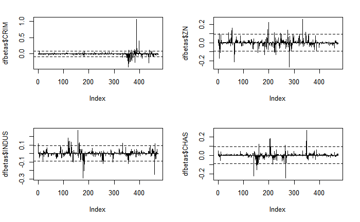

```r
par(mfrow = c(2,2))
```

```r
plot(dfbetas$NOX, type='h')
abline(h = thresh, lty = 2)
```

```r
abline(h = -thresh, lty = 2)

plot(dfbetas$RM, type='h')
```

```r
abline(h = thresh, lty = 2)
abline(h = -thresh, lty = 2)
```

```r
plot(dfbetas$AGE, type='h')
abline(h = thresh, lty = 2)
```

```r
abline(h = -thresh, lty = 2)

plot(dfbetas$DIS, type='h')
```

```r
abline(h = thresh, lty = 2)
abline(h = -thresh, lty = 2)
```

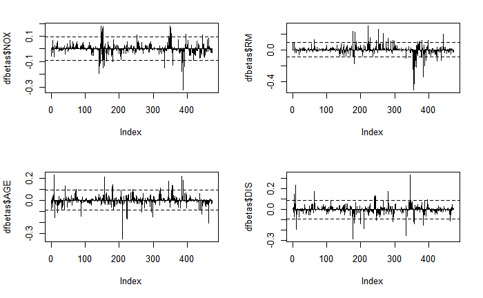

```r
par(mfrow = c(2,2))
```

```r
plot(dfbetas$RAD, type='h')
abline(h = thresh, lty = 2)
```

```r
abline(h = -thresh, lty = 2)

# plot(dfbetas$TAX, type='h')
# abline(h = thresh, lty = 2)
# abline(h = -thresh, lty = 2)

plot(dfbetas$PTRATIO, type='h')
```

```r
abline(h = thresh, lty = 2)
abline(h = -thresh, lty = 2)
```

```r
plot(dfbetas$B, type='h')
abline(h = thresh, lty = 2)
```

```r
abline(h = -thresh, lty = 2)

plot(dfbetas$LSTAT, type='h')
```

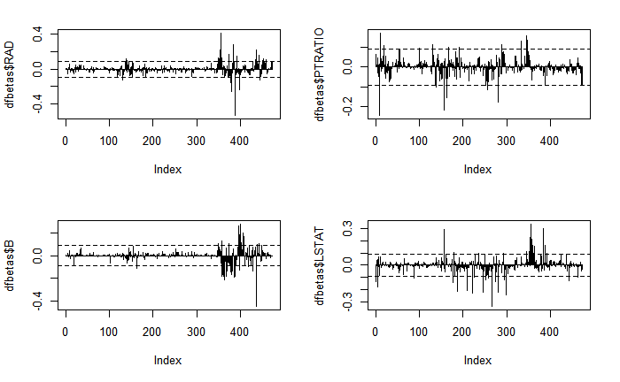

```r
abline(h = thresh, lty = 2)
abline(h = -thresh, lty = 2)
```

```r
outliers_wrt_CRIM<-leverages[dfbetas$CRIM>thresh]
cat("Influentials observations with respective to CRIM=",length(outliers_wrt_CRIM),"\n")
```

```
Influentials observations with respective to CRIM= 12
```

```r
outliers_wrt_ZN<-leverages[dfbetas$ZN>thresh]
cat("Influentials observations with respective to ZN=",length(outliers_wrt_ZN),"\n")
```

```
Influentials observations with respective to ZN= 13
```

```r
outliers_wrt_INDUS<-leverages[dfbetas$INDUS>thresh]
cat("Influentials observations with respective to INDUS=",length(outliers_wrt_INDUS),"\n")
```

```
Influentials observations with respective to INDUS= 13
```

```r
outliers_wrt_CHAS<-leverages[dfbetas$CHAS>thresh]
cat("Influentials observations with respective to CHAS=",length(outliers_wrt_CHAS),"\n")
```

```
Influentials observations with respective to CHAS= 7
```

```r
outliers_wrt_NOX<-leverages[dfbetas$NOX>thresh]
cat("Influentials observations with respective to NOX=",length(outliers_wrt_NOX),"\n")
```

```
Influentials observations with respective to NOX= 13
```

```r
outliers_wrt_RM<-leverages[dfbetas$RM>thresh]
cat("Influentials observations with respective to RM=",length(outliers_wrt_RM),"\n")
```

```
Influentials observations with respective to RM= 23
```

```r
outliers_wrt_AGE<-leverages[dfbetas$AGE>thresh]
cat("Influentials observations with respective to AGE=",length(outliers_wrt_AGE),"\n")
```

```
Influentials observations with respective to AGE= 17
```

```r
outliers_wrt_DIS<-leverages[dfbetas$DIS>thresh]
cat("Influentials observations with respective to DIS=",length(outliers_wrt_DIS),"\n")
```

```
Influentials observations with respective to DIS= 13
```

```r
outliers_wrt_RAD<-leverages[dfbetas$RAD>thresh]
cat("Influentials observations with respective to RAD=",length(outliers_wrt_RAD),"\n")
```

```
Influentials observations with respective to RAD= 20
```

```r
outliers_wrt_PTRATIO<-leverages[dfbetas$PTRATIO>thresh]
cat("Influentials observations with respective to PTRATIO=",length(outliers_wrt_PTRATIO),"\n")
```

```
Influentials observations with respective to PTRATIO= 12
```

```r
outliers_wrt_B<-leverages[dfbetas$B>thresh]
cat("Influentials observations with respective to B=",length(outliers_wrt_B),"\n")
```

```
Influentials observations with respective to B= 13
```

```r
outliers_wrt_LSTAT<-leverages[dfbetas$LSTAT>thresh]
cat("Influentials observations with respective to LSTAT=",length(outliers_wrt_LSTAT),"\n")
```

```
Influentials observations with respective to LSTAT= 20
```

### 4.2-12

Analysis of qualitative variable

t*=.1058293/.0441620 =2.396007001

t(0.95,472)=1.648088 thus making the CHAS significant

```r
library(dplyr)
near_river=outliers_removed %>% filter(outliers_removed$CHAS==1)
near_river
```

| CRIM | ZN | INDUS | CHAS | NOX | RM | AGE | DIS | RAD | PTRATIO | B | LSTAT | MEDV |
| --- | --- | --- | --- | --- | --- | --- | --- | --- | --- | --- | --- | --- |
| 3.32105 | 0 | 19.58 | 1 | 0.8710 | 5.403 | 100.0 | 1.3216 | 5 | 14.7 | 396.90 | 0.03728561 | 3.087099 |
| 1.12658 | 0 | 19.58 | 1 | 0.8710 | 5.012 | 88.0 | 1.6102 | 5 | 14.7 | 343.28 | 0.08250825 | 3.270114 |
| 1.41385 | 0 | 19.58 | 1 | 0.8710 | 6.129 | 96.0 | 1.7494 | 5 | 14.7 | 321.02 | 0.06613757 | 3.423240 |
| 3.53501 | 0 | 19.58 | 1 | 0.8710 | 6.152 | 82.6 | 1.7455 | 5 | 14.7 | 88.01 | 0.06657790 | 3.297811 |
| 1.27346 | 0 | 19.58 | 1 | 0.6050 | 6.250 | 92.6 | 1.7984 | 5 | 14.7 | 338.92 | 0.18181818 | 4.185077 |
| 1.51902 | 0 | 19.58 | 1 | 0.6050 | 8.375 | 93.9 | 2.1620 | 5 | 14.7 | 388.45 | 0.30120482 | 5.469359 |
| 0.13587 | 0 | 10.59 | 1 | 0.4890 | 6.064 | 59.1 | 4.2392 | 4 | 18.6 | 381.32 | 0.06821282 | 4.005010 |
| 0.43571 | 0 | 10.59 | 1 | 0.4890 | 5.344 | 100.0 | 3.8750 | 4 | 18.6 | 396.90 | 0.04330879 | 3.673616 |
| 0.17446 | 0 | 10.59 | 1 | 0.4890 | 5.960 | 92.1 | 3.8771 | 4 | 18.6 | 393.25 | 0.05790388 | 3.806120 |
| 0.37578 | 0 | 10.59 | 1 | 0.4890 | 5.404 | 88.6 | 3.6650 | 4 | 18.6 | 395.24 | 0.04170142 | 3.617207 |

[output cut: 20 more lines]

```r
count(near_river)
```

| n |
| --- |
| 30 |

```r
NA
```

```r
away_river=outliers_removed %>% filter(outliers_removed$CHAS==0)
count(away_river)
```

| n |
| --- |
| 442 |

```r
head(away_river)
```

|  | CRIM | ZN | INDUS | CHAS | NOX | RM | AGE | DIS | RAD | PTRATIO | B | LSTAT | MEDV |
| --- | --- | --- | --- | --- | --- | --- | --- | --- | --- | --- | --- | --- | --- |
| 1 | 0.00632 | 18 | 2.31 | 0 | 0.538 | 6.575 | 65.2 | 4.0900 | 1 | 15.3 | 396.90 | 0.2008032 | 3.976360 |
| 2 | 0.02731 | 0 | 7.07 | 0 | 0.469 | 6.421 | 78.9 | 4.9671 | 2 | 17.8 | 396.90 | 0.1094092 | 3.798492 |
| 3 | 0.02729 | 0 | 7.07 | 0 | 0.469 | 7.185 | 61.1 | 4.9671 | 2 | 17.8 | 392.83 | 0.2481390 | 4.666937 |
| 4 | 0.03237 | 0 | 2.18 | 0 | 0.458 | 6.998 | 45.8 | 6.0622 | 3 | 18.7 | 394.63 | 0.3401361 | 4.590175 |
| 5 | 0.06905 | 0 | 2.18 | 0 | 0.458 | 7.147 | 54.2 | 6.0622 | 3 | 18.7 | 396.90 | 0.1876173 | 4.753514 |
| 6 | 0.02985 | 0 | 2.18 | 0 | 0.458 | 6.430 | 58.7 | 6.0622 | 3 | 18.7 | 394.12 | 0.1919386 | 4.297554 |

```r
NA
```

### 4.2-13

identity test

```r
ttest=t.test(near_river$CRIM+near_river$ZN+near_river$INDUS+near_river$NOX+near_river$RM+near_river$AGE+near_river$DIS+near_river$RAD+
               near_river$PTRATIO+near_river$B+near_river$LSTAT,away_river$CRIM+away_river$ZN+away_river$INDUS+away_river$NOX+away_river$RM+away_river$AGE+away_river$DIS+away_river$RAD+away_river$PTRATIO+away_river$B+away_river$LSTAT,var.equal = TRUE)
ttest
```

```
    Two Sample t-test

data:  near_river$CRIM + near_river$ZN + near_river$INDUS + near_river$NOX + near_river$RM + near_river$AGE + near_river$DIS + near_river$RAD + near_river$PTRATIO + near_river$B + near_river$LSTAT and away_river$CRIM + away_river$ZN + away_river$INDUS + away_river$NOX + away_river$RM + away_river$AG…
t = 0.96389, df = 470, p-value = 0.3356
alternative hypothesis: true difference in means is not equal to 0
95 percent confidence interval:
 -15.17864  44.40661
sample estimates:
mean of x mean of y
 505.2807  490.6667
```

regression for each quantitative variable

```r
model2_1=lm(near_river$MEDV~near_river$CRIM+near_river$ZN+near_river$INDUS+near_river$NOX+near_river$RM+near_river$AGE+near_river$DIS+near_river$RAD+ near_river$PTRATIO+near_river$B+near_river$LSTAT)
summary(model2_1)
```

```
Call:
lm(formula = near_river$MEDV ~ near_river$CRIM + near_river$ZN +
    near_river$INDUS + near_river$NOX + near_river$RM + near_river$AGE +
    near_river$DIS + near_river$RAD + near_river$PTRATIO + near_river$B +
    near_river$LSTAT)

Residuals:
      Min        1Q    Median        3Q       Max
-0.234628 -0.053244 -0.000072  0.056790  0.134171

Coefficients:
                     Estimate Std. Error t value Pr(>|t|)
(Intercept)         2.0625646  0.8126532   2.538  0.02061 *
near_river$CRIM    -0.0168315  0.0244607  -0.688  0.50016
near_river$ZN      -0.0022256  0.0021893  -1.017  0.32282
near_river$INDUS    0.0258397  0.0094362   2.738  0.01350 *
near_river$NOX     -1.3625306  0.4679002  -2.912  0.00930 **
near_river$RM       0.3748071  0.0489503   7.657 4.55e-07 ***
near_river$AGE     -0.0009456  0.0020090  -0.471  0.64351
near_river$DIS      0.1147440  0.0542942   2.113  0.04879 *
near_river$RAD      0.0133461  0.0084572   1.578  0.13196
near_river$PTRATIO -0.0508831  0.0273492  -1.860  0.07923 .
near_river$B        0.0008331  0.0004876   1.709  0.10471
near_river$LSTAT    2.3154386  0.6069442   3.815  0.00127 **
---
Signif. codes:  0 ‘***’ 0.001 ‘**’ 0.01 ‘*’ 0.05 ‘.’ 0.1 ‘ ’ 1

Residual standard error: 0.1115 on 18 degrees of freedom
Multiple R-squared:  0.9794,    Adjusted R-squared:  0.9668
F-statistic: 77.83 on 11 and 18 DF,  p-value: 7.444e-13
```

```r
model2_2=lm(away_river$MEDV~away_river$CRIM+away_river$ZN+away_river$INDUS+away_river$NOX+away_river$RM+away_river$AGE+away_river$DIS+away_river$RAD+away_river$PTRATIO+away_river$B+away_river$LSTAT)
summary(model2_2)
```

```
Call:
lm(formula = away_river$MEDV ~ away_river$CRIM + away_river$ZN +
    away_river$INDUS + away_river$NOX + away_river$RM + away_river$AGE +
    away_river$DIS + away_river$RAD + away_river$PTRATIO + away_river$B +
    away_river$LSTAT)

Residuals:
     Min       1Q   Median       3Q      Max
-0.74623 -0.13206 -0.01634  0.13045  0.99314

Coefficients:
                     Estimate Std. Error t value Pr(>|t|)
(Intercept)         3.2771912  0.2787984  11.755  < 2e-16 ***
away_river$CRIM    -0.0194411  0.0030589  -6.356 5.30e-10 ***
away_river$ZN      -0.0002765  0.0007024  -0.394  0.69399
away_river$INDUS   -0.0049798  0.0029268  -1.701  0.08959 .
away_river$NOX     -0.8282984  0.2104463  -3.936 9.66e-05 ***
away_river$RM       0.2863144  0.0279166  10.256  < 2e-16 ***
away_river$AGE     -0.0021697  0.0007058  -3.074  0.00224 **
away_river$DIS     -0.0715473  0.0105685  -6.770 4.24e-11 ***
away_river$RAD      0.0035329  0.0024291   1.454  0.14656
away_river$PTRATIO -0.0542355  0.0067376  -8.050 8.20e-15 ***
away_river$B        0.0009071  0.0001477   6.142 1.86e-09 ***
away_river$LSTAT    3.1040771  0.3182795   9.753  < 2e-16 ***
---
Signif. codes:  0 ‘***’ 0.001 ‘**’ 0.01 ‘*’ 0.05 ‘.’ 0.1 ‘ ’ 1

Residual standard error: 0.2324 on 430 degrees of freedom
Multiple R-squared:  0.8425,    Adjusted R-squared:  0.8385
F-statistic: 209.2 on 11 and 430 DF,  p-value: < 2.2e-16
```

### 4.2-14

ridge regression

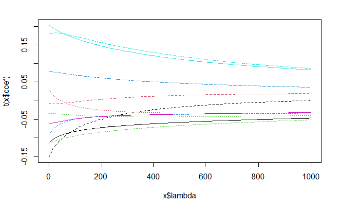

```r
#model2=lm(formula = MEDV ~ CRIM+ZN+INDUS+CHAS+NOX+RM+AGE+DIS+RAD+PTRATIO+B+LSTAT, data = data1)
#summary(model2)
library(MASS)

fit.ridge<-lm.ridge(MEDV ~ CRIM+ZN+INDUS+NOX+RM+AGE+DIS+RAD+PTRATIO+B+LSTAT, data=away_river, lambda=seq(0,1000,10))
plot(fit.ridge)
```

```r
summary(fit.ridge)
```

```
       Length Class  Mode
coef   1111   -none- numeric
scales   11   -none- numeric
Inter     1   -none- numeric
lambda  101   -none- numeric
ym        1   -none- numeric
xm       11   -none- numeric
GCV     101   -none- numeric
kHKB      1   -none- numeric
kLW       1   -none- numeric
```

```r
y <- away_river$MEDV
x <- data.matrix(away_river [, c('CRIM','ZN','INDUS','NOX','RM','AGE','DIS','RAD','PTRATIO','B','LSTAT')])
library(glmnet)
modeltest <- glmnet(x, y, alpha = 0)

summary(modeltest)
```

```
          Length Class     Mode
a0         100   -none-    numeric
beta      1100   dgCMatrix S4
df         100   -none-    numeric
dim          2   -none-    numeric
lambda     100   -none-    numeric
dev.ratio  100   -none-    numeric
nulldev      1   -none-    numeric
npasses      1   -none-    numeric
jerr         1   -none-    numeric
offset       1   -none-    logical
call         4   -none-    call
nobs         1   -none-    numeric
```

estimating best lambda

```r
cv_model <- cv.glmnet(x, y, alpha = 0)
best_lambda <- cv_model$lambda.min
best_lambda
```

```
[1] 0.04676432
```

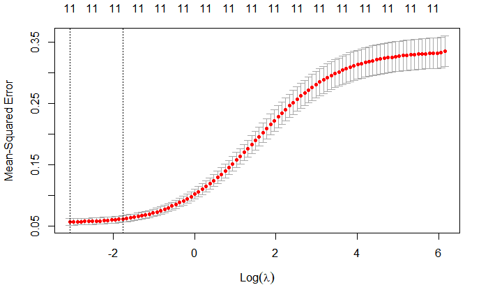

```r
plot(cv_model)
```

```r
NA
NA
NA
NA
NA
```

final modelridge coeff

```r
best_model <- glmnet(x, y, alpha = 0, lambda = best_lambda)
coef(best_model)
```

```
12 x 1 sparse Matrix of class "dgCMatrix"
                       s0
(Intercept)  3.0061580034
CRIM        -0.0163038643
ZN          -0.0003071998
INDUS       -0.0052914923
NOX         -0.5868710968
RM           0.2904070846
AGE         -0.0020046453
DIS         -0.0529332602
RAD          0.0004748944
PTRATIO     -0.0492540476
B            0.0008702578
LSTAT        2.8508241951
```

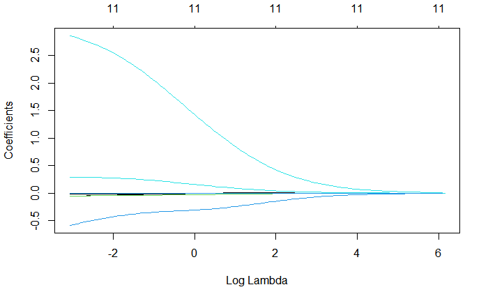

```r
plot(modeltest, xvar = "lambda")
```

```r
y_predicted <- predict(modeltest, s = best_lambda, newx = x)

#find SST and SSE
sst <- sum((y - mean(y))^2)
sse <- sum((y_predicted - y)^2)

#find R-Squared
rsq <- 1 - sse/sst
rsq
```

```
[1] 0.8395315
```

regression tree

```r
library(ISLR) #contains Hitters dataset
library(rpart) #for fitting decision trees
library(rpart.plot) #for plotting decision trees

#build the initial tree
tree <- rpart(MEDV ~ CRIM+ZN+INDUS+NOX+RM+AGE+DIS+RAD+PTRATIO+B+LSTAT, data=away_river, control=rpart.control(cp=.001))

#view results
printcp(tree)
```

```
Regression tree:
rpart(formula = MEDV ~ CRIM + ZN + INDUS + NOX + RM + AGE + DIS +
    RAD + PTRATIO + B + LSTAT, data = away_river, control = rpart.control(cp = 0.001))

Variables actually used in tree construction:
 [1] AGE     B       CRIM    DIS     INDUS   LSTAT   NOX     PTRATIO RAD     RM

Root node error: 147.43/442 = 0.33356

n= 442

          CP nsplit rel error  xerror     xstd
1  0.4549333      0  1.000000 1.00414 0.076519
2  0.1558377      1  0.545067 0.58457 0.040423
3  0.1157723      2  0.389229 0.42088 0.028985
```

[output cut: 24 more lines]

prune the regression tree to find the optimal value to use for cp (the complexity parameter) that leads to the lowest test error.

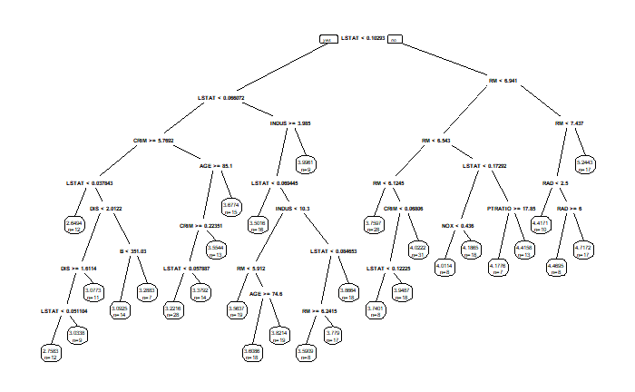

```r
best <- tree$cptable[which.min(tree$cptable[,"xerror"]),"CP"]

#produce a pruned tree based on the best cp value
pruned_tree <- prune(tree, cp=best)

#plot the pruned tree
prp(pruned_tree,
    faclen=0, #use full names for factor labels
    extra=1, #display number of obs. for each terminal node
    roundint=F, #don't round to integers in output
    digits=5) #display 5 decimal places in output
```

```r
best
```

```
[1] 0.001
```

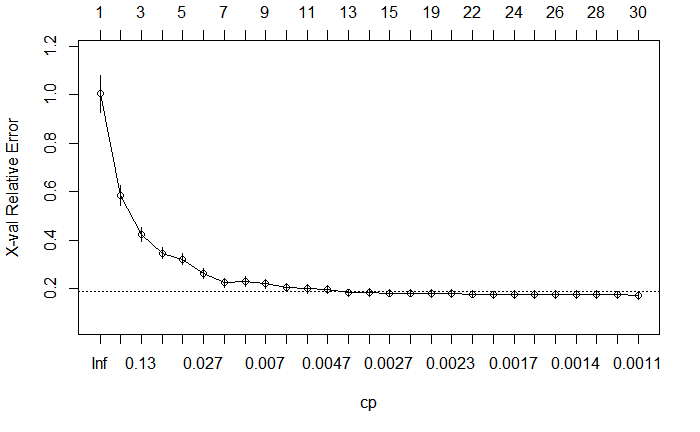

```r
plotcp(pruned_tree)
```

```r
new <- data.frame(CRIM=0.1396,ZN=0,INDUS=8.56,CHAS=0,NOX=0.52,RM=6.167,AGE=90,DIS=2.421,RAD=5,PTRATIO=20.9,B=392.69,LSTAT=12.33)

#use pruned tree to predict salary of this player
predict(pruned_tree, newdata=new)
```

```
       1
4.022163
```

Regreesion tree 1

```r
library(MASS)
data(away_river)
str(away_river)
```

```
'data.frame':   442 obs. of  13 variables:
 $ CRIM   : num  0.00632 0.02731 0.02729 0.03237 0.06905 ...
 $ ZN     : num  18 0 0 0 0 0 12.5 12.5 12.5 12.5 ...
 $ INDUS  : num  2.31 7.07 7.07 2.18 2.18 2.18 7.87 7.87 7.87 7.87 ...
 $ CHAS   : int  0 0 0 0 0 0 0 0 0 0 ...
 $ NOX    : num  0.538 0.469 0.469 0.458 0.458 0.458 0.524 0.524 0.524 0.524 ...
 $ RM     : num  6.58 6.42 7.18 7 7.15 ...
 $ AGE    : num  65.2 78.9 61.1 45.8 54.2 58.7 66.6 96.1 100 85.9 ...
 $ DIS    : num  4.09 4.97 4.97 6.06 6.06 ...
 $ RAD    : int  1 2 2 3 3 3 5 5 5 5 ...
 $ PTRATIO: num  15.3 17.8 17.8 18.7 18.7 18.7 15.2 15.2 15.2 15.2 ...
 $ B      : num  397 397 393 395 397 ...
 $ LSTAT  : num  0.201 0.109 0.248 0.34 0.188 ...
 $ MEDV   : num  3.98 3.8 4.67 4.59 4.75 ...
```

```r
library(rpart)
model = rpart(MEDV ~ CRIM+ZN+INDUS+NOX+RM+AGE+DIS+RAD+PTRATIO+B+LSTAT, data = away_river)
model
```

```
n= 442

node), split, n, deviance, yval
      * denotes terminal node

 1) root 442 147.4317000 3.767866
   2) LSTAT< 0.1029343 259  41.1577700 3.440425
     4) LSTAT< 0.06607237 135  17.1920100 3.194393
       8) CRIM>=5.76921 65   5.4073890 2.959399 *
       9) CRIM< 5.76921 70   4.8621670 3.412601 *
     5) LSTAT>=0.06607237 124   6.8972510 3.708282 *
   3) LSTAT>=0.1029343 183  39.2023300 4.231295
     6) RM< 6.941 131   8.3941870 4.008055
      12) RM< 6.543 85   3.0865300 3.893622 *
      13) RM>=6.543 46   2.1378380 4.219507 *
     7) RM>=6.941 52   7.8327270 4.793688
      14) RM< 7.437 35   1.9795890 4.574837 *
      15) RM>=7.437 17   0.7254568 5.244264 *
```

Modeling Decision Regression in R with Caret

```r
library(caret)
set.seed(1)

model <- train(
  MEDV ~ CRIM+ZN+INDUS+NOX+RM+AGE+DIS+RAD+PTRATIO+B+LSTAT,
  data = away_river,
  method = 'rpart2'
)
model
```

```
CART

442 samples
 11 predictor

No pre-processing
Resampling: Bootstrapped (25 reps)
Summary of sample sizes: 442, 442, 442, 442, 442, 442, ...
Resampling results across tuning parameters:

  maxdepth  RMSE       Rsquared   MAE
  1         0.4504976  0.3920963  0.3536817
  2         0.3654602  0.5992302  0.2780696
  3         0.2876724  0.7495510  0.2191226

RMSE was used to select the optimal model using the smallest value.
The final value used for the model was maxdepth = 3.
```

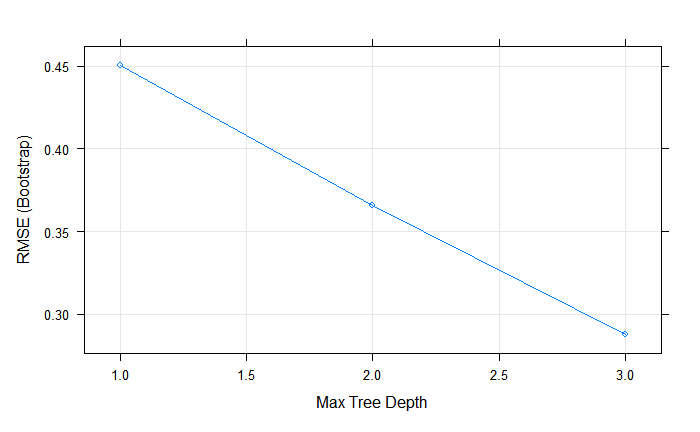

```r
plot(model)
```

Preprocessing with Caret We will center and scale our data by passing the following to the train method:

```r
set.seed(1)

model2 <- train(
  MEDV ~ CRIM+ZN+INDUS+NOX+RM+AGE+DIS+RAD+PTRATIO+B+LSTAT,
  data = away_river,
  method = 'rpart2',
  preProcess = c("center", "scale")
)
model2
```

```
CART

442 samples
 11 predictor

Pre-processing: centered (11), scaled (11)
Resampling: Bootstrapped (25 reps)
Summary of sample sizes: 442, 442, 442, 442, 442, 442, ...
Resampling results across tuning parameters:

  maxdepth  RMSE       Rsquared   MAE
  1         0.4504976  0.3920963  0.3536817
  2         0.3654602  0.5992302  0.2780696
  3         0.2876724  0.7495510  0.2191226

RMSE was used to select the optimal model using the smallest value.
The final value used for the model was maxdepth = 3.
```

Splitting the Data Set 80/20 split

```r
set.seed(1)

inTraining <- createDataPartition(away_river$MEDV, p = .80, list = FALSE)
training <- away_river[inTraining,]
testing  <- away_river[-inTraining,]
```

```r
set.seed(1)
model3 <- train(
  MEDV ~ CRIM+ZN+INDUS+NOX+RM+AGE+DIS+RAD+PTRATIO+B+LSTAT,
  data = training,
  method = 'rpart2',
  preProcess = c("center", "scale")
)
model3
```

```
CART

354 samples
 11 predictor

Pre-processing: centered (11), scaled (11)
Resampling: Bootstrapped (25 reps)
Summary of sample sizes: 354, 354, 354, 354, 354, 354, ...
Resampling results across tuning parameters:

  maxdepth  RMSE       Rsquared   MAE
  1         0.4519093  0.3912079  0.3584814
  2         0.3725848  0.5827427  0.2829973
  3         0.2936338  0.7396357  0.2211978

RMSE was used to select the optimal model using the smallest value.
The final value used for the model was maxdepth = 3.
```

testing

```r
test.features = subset(testing, select=-c(MEDV))
test.target = subset(testing, select=MEDV)[,1]

predictions = predict(model3, newdata = test.features)

# RMSE
sqrt(mean((test.target - predictions)^2))
```

```
[1] 0.2576786
```

```r
# R2
cor(test.target, predictions) ^ 2
```

```
[1] 0.812813
```

use a data partitioning strategy like k-fold cross-validation that resamples and splits our data many times. We then train the model on these samples and pick the best model.

```r
set.seed(1)
ctrl <- trainControl(
  method = "cv",
  number = 10,
)
model4 <- train(
  MEDV ~ CRIM+ZN+INDUS+CHAS+NOX+RM+AGE+DIS+RAD+PTRATIO+B+LSTAT,
  data = training,
  method = 'rpart2',
  preProcess = c("center", "scale"),
  trControl = ctrl
)
model4
```

```
CART

354 samples
 12 predictor

Pre-processing: centered (12), scaled (12)
Resampling: Cross-Validated (10 fold)
Summary of sample sizes: 319, 318, 318, 318, 319, 319, ...
Resampling results across tuning parameters:

  maxdepth  RMSE       Rsquared   MAE
  1         0.4311701  0.4510207  0.3528997
  2         0.3521486  0.6349897  0.2750322
  3         0.2704891  0.7820814  0.2074601

RMSE was used to select the optimal model using the smallest value.
The final value used for the model was maxdepth = 3.
```

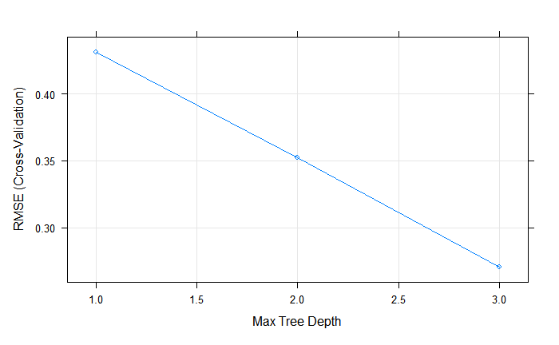

```r
plot(model4)
```

```r
test.features = subset(testing, select=-c(MEDV))
test.target = subset(testing, select=MEDV)[,1]

predictions = predict(model4, newdata = test.features)

# RMSE
sqrt(mean((test.target - predictions)^2))
```

```
[1] 0.2576786
```

```r
# R2
cor(test.target, predictions) ^ 2
```

```
[1] 0.812813
```

### 4.2-15

Robust regression

When there is no time for a thorough identification of outlying cases and an analysis of their influence, nor for a careful consideration of remedial measures. Instead, an automated regression calibration must be used. Robust regression procedures will automatically guard against undue influence of outlying cases in this situation.

From the plot we can see that there are observations with standardized residuals as outliers.

```r
ols=lm(formula = MEDV ~ ., data = data1)
summary(ols)
```

```
Call:
lm(formula = MEDV ~ ., data = data1)

Residuals:
     Min       1Q   Median       3Q      Max
-14.1711  -2.4566  -0.3049   1.8076  27.6406

Coefficients:
              Estimate Std. Error t value Pr(>|t|)
(Intercept)  24.046732   4.451785   5.402 1.03e-07 ***
CRIM         -0.161304   0.029715  -5.428 8.94e-08 ***
ZN           -0.001774   0.012393  -0.143 0.886222
INDUS        -0.128431   0.050468  -2.545 0.011239 *
CHAS          2.236892   0.785773   2.847 0.004601 **
NOX         -17.339817   3.487415  -4.972 9.16e-07 ***
RM            3.032016   0.383348   7.909 1.71e-14 ***
AGE           0.004540   0.011833   0.384 0.701394
DIS          -1.172149   0.184154  -6.365 4.47e-10 ***
RAD           0.138162   0.037370   3.697 0.000243 ***
PTRATIO      -0.891371   0.119669  -7.449 4.25e-13 ***
B             0.009860   0.002441   4.039 6.21e-05 ***
LSTAT        59.245699   3.858366  15.355  < 2e-16 ***
---
Signif. codes:  0 ‘***’ 0.001 ‘**’ 0.01 ‘*’ 0.05 ‘.’ 0.1 ‘ ’ 1

Residual standard error: 4.342 on 493 degrees of freedom
Multiple R-squared:  0.7824,    Adjusted R-squared:  0.7771
F-statistic: 147.8 on 12 and 493 DF,  p-value: < 2.2e-16
```

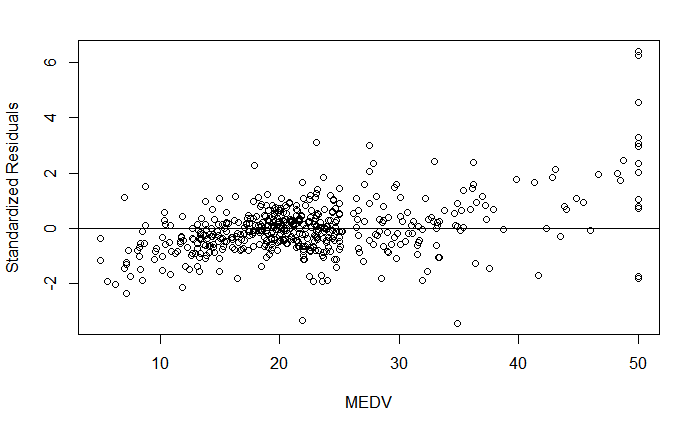

```r
plot(data1$MEDV, rstandard(ols), ylab='Standardized Residuals', xlab='MEDV')
abline(h=0)
```

```r
library(MASS)
robust <- rlm(formula =MEDV ~ ., data = data1)
```

RSE of ordinary least square regression model and Robust regression model

```r
summary(ols)$sigma
```

```
[1] 4.341684
```

```r
summary(robust)$sigma
```

```
[1] 2.829979
```

Model summary comparison of ordinary least square regression model and Robust regression model

```r
summary(ols)
```

```
Call:
lm(formula = MEDV ~ ., data = data1)

Residuals:
     Min       1Q   Median       3Q      Max
-14.1711  -2.4566  -0.3049   1.8076  27.6406

Coefficients:
              Estimate Std. Error t value Pr(>|t|)
(Intercept)  24.046732   4.451785   5.402 1.03e-07 ***
CRIM         -0.161304   0.029715  -5.428 8.94e-08 ***
ZN           -0.001774   0.012393  -0.143 0.886222
INDUS        -0.128431   0.050468  -2.545 0.011239 *
CHAS          2.236892   0.785773   2.847 0.004601 **
NOX         -17.339817   3.487415  -4.972 9.16e-07 ***
RM            3.032016   0.383348   7.909 1.71e-14 ***
AGE           0.004540   0.011833   0.384 0.701394
DIS          -1.172149   0.184154  -6.365 4.47e-10 ***
RAD           0.138162   0.037370   3.697 0.000243 ***
PTRATIO      -0.891371   0.119669  -7.449 4.25e-13 ***
B             0.009860   0.002441   4.039 6.21e-05 ***
LSTAT        59.245699   3.858366  15.355  < 2e-16 ***
---
Signif. codes:  0 ‘***’ 0.001 ‘**’ 0.01 ‘*’ 0.05 ‘.’ 0.1 ‘ ’ 1

Residual standard error: 4.342 on 493 degrees of freedom
Multiple R-squared:  0.7824,    Adjusted R-squared:  0.7771
F-statistic: 147.8 on 12 and 493 DF,  p-value: < 2.2e-16
```

```r
summary(robust)
```

```
Call: rlm(formula = MEDV ~ ., data = data1)
Residuals:
     Min       1Q   Median       3Q      Max
-13.8209  -1.8300  -0.2818   2.0096  29.2747

Coefficients:
            Value    Std. Error t value
(Intercept)  14.5892   3.3810     4.3150
CRIM         -0.1395   0.0226    -6.1806
ZN            0.0053   0.0094     0.5649
INDUS        -0.0868   0.0383    -2.2656
CHAS          1.8059   0.5968     3.0261
NOX         -12.4803   2.6486    -4.7120
RM            3.8870   0.2911    13.3508
AGE          -0.0128   0.0090    -1.4225
DIS          -0.9872   0.1399    -7.0583
RAD           0.0537   0.0284     1.8908
PTRATIO      -0.7598   0.0909    -8.3601
B             0.0110   0.0019     5.9442
LSTAT        49.2415   2.9303    16.8040

Residual standard error: 2.83 on 493 degrees of freedom
```

We can see that roughly, as the absolute residual goes down, the weight goes up. In other words, cases with a large residuals tend to be down-weighted.Hence, the more cases in the robust regression that have a weight close to one, the closer the results of the OLS and robust regressions.

Since we are not able to get Adjusted r square from robust regression fitted model using “rlm” function of MASS library. We just fit the robust regression model and extract weights from the fitted model and use it to fit model using “lm” function with weights parameter.

```r
wei_data1<-data1
wei_data1["absolute resid"]<-c(abs(robust$resid))
wei_data1["weight"]<-c(robust$w)
print(wei_data1[1:30,])
```

|  | CRIM | ZN | INDUS | CHAS | NOX | RM | AGE | DIS | RAD | PTRATIO | B | MEDV | LSTAT | absolute resid | weight |
| --- | --- | --- | --- | --- | --- | --- | --- | --- | --- | --- | --- | --- | --- | --- | --- |
| 1 | 0.00632 | 18.0 | 2.31 | 0 | 0.538 | 6.575 | 65.2 | 4.0900 | 1 | 15.3 | 396.90 | 24.0 | 0.20080321 | 7.145112019 | 0.5326758 |
| 2 | 0.02731 | 0.0 | 7.07 | 0 | 0.469 | 6.421 | 78.9 | 4.9671 | 2 | 17.8 | 396.90 | 21.6 | 0.10940919 | 1.908403759 | 1.0000000 |
| 3 | 0.02729 | 0.0 | 7.07 | 0 | 0.469 | 7.185 | 61.1 | 4.9671 | 2 | 17.8 | 392.83 | 34.7 | 0.24813896 | 1.207968435 | 1.0000000 |
| 4 | 0.03237 | 0.0 | 2.18 | 0 | 0.458 | 6.998 | 45.8 | 6.0622 | 3 | 18.7 | 394.63 | 33.4 | 0.34013605 | 2.960644770 | 1.0000000 |
| 5 | 0.06905 | 0.0 | 2.18 | 0 | 0.458 | 7.147 | 54.2 | 6.0622 | 3 | 18.7 | 396.90 | 36.2 | 0.18761726 | 6.857927092 | 0.5550366 |
| 6 | 0.02985 | 0.0 | 2.18 | 0 | 0.458 | 6.430 | 58.7 | 6.0622 | 3 | 18.7 | 394.12 | 28.7 | 0.19193858 | 2.014813362 | 1.0000000 |
| 7 | 0.08829 | 12.5 | 7.87 | 0 | 0.524 | 6.012 | 66.6 | 5.5605 | 5 | 15.2 | 395.60 | 22.9 | 0.08045052 | 1.411652693 | 1.0000000 |
| 8 | 0.14455 | 12.5 | 7.87 | 0 | 0.524 | 6.172 | 96.1 | 5.9505 | 5 | 15.2 | 396.90 | 27.1 | 0.05221932 | 7.135505839 | 0.5334220 |
| 9 | 0.21124 | 12.5 | 7.87 | 0 | 0.524 | 5.631 | 100.0 | 6.0821 | 5 | 15.2 | 386.63 | 16.5 | 0.03341129 | 0.133244272 | 1.0000000 |
| 10 | 0.17004 | 12.5 | 7.87 | 0 | 0.524 | 6.004 | 85.9 | 6.5921 | 5 | 15.2 | 386.71 | 18.9 | 0.05847953 | 0.100900175 | 1.0000000 |

[output cut: 20 more lines]

We can observe that,

From Ordinary least square regression the Adjusted Rsquare is 0.7771 and Residual standard error is 4.342.

From Robust regression model using Huber weights the Adjusted Rsquare is 0.8489 and Residual standard error is 3.062.

Hence, Residual standard error is reduced and Adjusted Rsquare is increased

```r
ols <- lm(formula = MEDV ~ ., data = data1)
robust.weighted <- lm(formula = MEDV ~ ., data = data1,weights=robust$w)
summary(ols)
```

```
Call:
lm(formula = MEDV ~ ., data = data1)

Residuals:
     Min       1Q   Median       3Q      Max
-14.1711  -2.4566  -0.3049   1.8076  27.6406

Coefficients:
              Estimate Std. Error t value Pr(>|t|)
(Intercept)  24.046732   4.451785   5.402 1.03e-07 ***
CRIM         -0.161304   0.029715  -5.428 8.94e-08 ***
ZN           -0.001774   0.012393  -0.143 0.886222
INDUS        -0.128431   0.050468  -2.545 0.011239 *
CHAS          2.236892   0.785773   2.847 0.004601 **
NOX         -17.339817   3.487415  -4.972 9.16e-07 ***
RM            3.032016   0.383348   7.909 1.71e-14 ***
AGE           0.004540   0.011833   0.384 0.701394
DIS          -1.172149   0.184154  -6.365 4.47e-10 ***
RAD           0.138162   0.037370   3.697 0.000243 ***
PTRATIO      -0.891371   0.119669  -7.449 4.25e-13 ***
B             0.009860   0.002441   4.039 6.21e-05 ***
LSTAT        59.245699   3.858366  15.355  < 2e-16 ***
---
Signif. codes:  0 ‘***’ 0.001 ‘**’ 0.01 ‘*’ 0.05 ‘.’ 0.1 ‘ ’ 1

Residual standard error: 4.342 on 493 degrees of freedom
Multiple R-squared:  0.7824,    Adjusted R-squared:  0.7771
F-statistic: 147.8 on 12 and 493 DF,  p-value: < 2.2e-16
```

```r
summary(robust.weighted)
```

```
Call:
lm(formula = MEDV ~ ., data = data1, weights = robust$w)

Weighted Residuals:
    Min      1Q  Median      3Q     Max
-7.2531 -1.8300 -0.2818  2.0096 10.5561

Coefficients:
              Estimate Std. Error t value Pr(>|t|)
(Intercept)  14.589216   3.438874   4.242 2.64e-05 ***
CRIM         -0.139485   0.022471  -6.207 1.15e-09 ***
ZN            0.005317   0.009146   0.581  0.56126
INDUS        -0.086841   0.036937  -2.351  0.01911 *
CHAS          1.805914   0.583849   3.093  0.00209 **
NOX         -12.480317   2.542992  -4.908 1.25e-06 ***
RM            3.887006   0.329157  11.809  < 2e-16 ***
AGE          -0.012783   0.008786  -1.455  0.14634
DIS          -0.987188   0.137022  -7.205 2.19e-12 ***
RAD           0.053665   0.027805   1.930  0.05418 .
PTRATIO      -0.759818   0.087331  -8.700  < 2e-16 ***
B             0.011020   0.001820   6.055 2.78e-09 ***
LSTAT        49.241513   3.174297  15.513  < 2e-16 ***
---
Signif. codes:  0 ‘***’ 0.001 ‘**’ 0.01 ‘*’ 0.05 ‘.’ 0.1 ‘ ’ 1

Residual standard error: 3.062 on 493 degrees of freedom
Multiple R-squared:  0.8525,    Adjusted R-squared:  0.8489
F-statistic: 237.5 on 12 and 493 DF,  p-value: < 2.2e-16
```

Applying Robust Regression on dataset of which response variable is transformed using Box Cox method.

We can observe that,

Hence, Residual standard error is reduced and Adjusted Rsquare is increased

```r
library(MASS)


ols=lm(formula = MEDV ~ ., data = trans_data1)

robust <- rlm(formula =MEDV ~ ., data = trans_data1)

robust.weighted <- lm(formula = MEDV ~ ., data = trans_data1,weights=robust$w)
summary(ols)
```

```
Call:
lm(formula = MEDV ~ ., data = trans_data1)

Residuals:
     Min       1Q   Median       3Q      Max
-1.00454 -0.16296 -0.01559  0.14856  1.76635

Coefficients:
              Estimate Std. Error t value Pr(>|t|)
(Intercept)  4.1197397  0.3230326  12.753  < 2e-16 ***
CRIM        -0.0167338  0.0021562  -7.761 4.91e-14 ***
ZN          -0.0007740  0.0008993  -0.861 0.389854
INDUS       -0.0089527  0.0036621  -2.445 0.014848 *
CHAS         0.1644304  0.0570176   2.884 0.004100 **
NOX         -1.3329768  0.2530556  -5.268 2.07e-07 ***
RM           0.2022404  0.0278167   7.270 1.41e-12 ***
AGE         -0.0005344  0.0008586  -0.622 0.533932
DIS         -0.0757576  0.0133627  -5.669 2.44e-08 ***
RAD          0.0093114  0.0027117   3.434 0.000645 ***
PTRATIO     -0.0639371  0.0086835  -7.363 7.59e-13 ***
B            0.0008116  0.0001771   4.582 5.83e-06 ***
LSTAT        3.7803187  0.2799727  13.502  < 2e-16 ***
---
Signif. codes:  0 ‘***’ 0.001 ‘**’ 0.01 ‘*’ 0.05 ‘.’ 0.1 ‘ ’ 1

Residual standard error: 0.315 on 493 degrees of freedom
Multiple R-squared:  0.7797,    Adjusted R-squared:  0.7743
F-statistic: 145.4 on 12 and 493 DF,  p-value: < 2.2e-16
```

```r
summary(robust.weighted)
```

```
Call:
lm(formula = MEDV ~ ., data = trans_data1, weights = robust$w)

Weighted Residuals:
     Min       1Q   Median       3Q      Max
-0.52443 -0.13102 -0.01007  0.15651  0.71177

Coefficients:
              Estimate Std. Error t value Pr(>|t|)
(Intercept)  3.0801630  0.2520396  12.221  < 2e-16 ***
CRIM        -0.0152916  0.0017372  -8.802  < 2e-16 ***
ZN          -0.0003784  0.0006580  -0.575  0.56551
INDUS       -0.0054733  0.0027147  -2.016  0.04432 *
CHAS         0.1234428  0.0425383   2.902  0.00387 **
NOX         -0.9089454  0.1880467  -4.834 1.79e-06 ***
RM           0.3194611  0.0236748  13.494  < 2e-16 ***
AGE         -0.0019889  0.0006415  -3.101  0.00204 **
DIS         -0.0651590  0.0099532  -6.547 1.48e-10 ***
RAD          0.0035040  0.0020718   1.691  0.09141 .
PTRATIO     -0.0556392  0.0063791  -8.722  < 2e-16 ***
B            0.0010366  0.0001377   7.529 2.45e-13 ***
LSTAT        2.7847134  0.2292996  12.144  < 2e-16 ***
---
Signif. codes:  0 ‘***’ 0.001 ‘**’ 0.01 ‘*’ 0.05 ‘.’ 0.1 ‘ ’ 1

Residual standard error: 0.2243 on 493 degrees of freedom
Multiple R-squared:  0.8576,    Adjusted R-squared:  0.8542
F-statistic: 247.5 on 12 and 493 DF,  p-value: < 2.2e-16
```

Applying Robust Regression on dataset of which response variable is transformed using Box Cox method and outlying observations removed using Cook’s distance.

We can observe that,

From Ordinary least square regression the Adjusted R square is 0.8469 and Residual standard error is 0.2283.

From Robust regression model using Huber weights the Adjusted R square is 0.881 and Residual standard error is 0.1888.

Hence, Residual standard error is reduced and Adjusted Rsquare is increased

```r
ols=lm(formula = MEDV ~ ., data = outliers_removed)

robust <- rlm(formula =MEDV ~ ., data = outliers_removed)

robust.weighted <- lm(formula = MEDV ~ ., data = outliers_removed,weights=robust$w)
summary(ols)
```

```
Call:
lm(formula = MEDV ~ ., data = outliers_removed)

Residuals:
     Min       1Q   Median       3Q      Max
-0.75124 -0.12860 -0.01593  0.12369  0.99120

Coefficients:
              Estimate Std. Error t value Pr(>|t|)
(Intercept)  3.2196814  0.2637953  12.205  < 2e-16 ***
CRIM        -0.0195262  0.0029752  -6.563 1.43e-10 ***
ZN          -0.0003458  0.0006764  -0.511  0.60949
INDUS       -0.0048341  0.0028029  -1.725  0.08526 .
CHAS         0.1058293  0.0441620   2.396  0.01696 *
NOX         -0.9008653  0.1905821  -4.727 3.04e-06 ***
RM           0.2938727  0.0263769  11.141  < 2e-16 ***
AGE         -0.0020784  0.0006715  -3.095  0.00209 **
DIS         -0.0703592  0.0101950  -6.901 1.72e-11 ***
RAD          0.0042491  0.0023223   1.830  0.06794 .
PTRATIO     -0.0527304  0.0064843  -8.132 3.97e-15 ***
B            0.0009373  0.0001427   6.570 1.37e-10 ***
LSTAT        3.0433556  0.2961081  10.278  < 2e-16 ***
---
Signif. codes:  0 ‘***’ 0.001 ‘**’ 0.01 ‘*’ 0.05 ‘.’ 0.1 ‘ ’ 1

Residual standard error: 0.2283 on 459 degrees of freedom
Multiple R-squared:  0.8508,    Adjusted R-squared:  0.8469
F-statistic: 218.2 on 12 and 459 DF,  p-value: < 2.2e-16
```

```r
summary(robust.weighted)
```

```
Call:
lm(formula = MEDV ~ ., data = outliers_removed, weights = robust$w)

Weighted Residuals:
     Min       1Q   Median       3Q      Max
-0.43093 -0.12157 -0.00863  0.13248  0.51121

Coefficients:
              Estimate Std. Error t value Pr(>|t|)
(Intercept)  2.840e+00  2.301e-01  12.339  < 2e-16 ***
CRIM        -2.132e-02  2.805e-03  -7.600 1.69e-13 ***
ZN          -2.845e-05  5.740e-04  -0.050  0.96050
INDUS       -3.538e-03  2.387e-03  -1.482  0.13899
CHAS         1.128e-01  3.693e-02   3.055  0.00238 **
NOX         -7.716e-01  1.625e-01  -4.748 2.75e-06 ***
RM           3.313e-01  2.369e-02  13.988  < 2e-16 ***
AGE         -2.346e-03  5.782e-04  -4.057 5.84e-05 ***
DIS         -6.581e-02  8.757e-03  -7.516 2.99e-13 ***
RAD          3.803e-03  2.033e-03   1.871  0.06197 .
PTRATIO     -5.029e-02  5.483e-03  -9.172  < 2e-16 ***
B            1.064e-03  1.238e-04   8.596  < 2e-16 ***
LSTAT        2.727e+00  2.593e-01  10.517  < 2e-16 ***
---
Signif. codes:  0 ‘***’ 0.001 ‘**’ 0.01 ‘*’ 0.05 ‘.’ 0.1 ‘ ’ 1

Residual standard error: 0.1888 on 459 degrees of freedom
Multiple R-squared:  0.884, Adjusted R-squared:  0.881
F-statistic: 291.5 on 12 and 459 DF,  p-value: < 2.2e-16
```

### 4.2-16

Random Forest

```r
library(caret)
set.seed(1)


head(away_river)
```

|  | CRIM | ZN | INDUS | CHAS | NOX | RM | AGE | DIS | RAD | PTRATIO | B | LSTAT | MEDV |
| --- | --- | --- | --- | --- | --- | --- | --- | --- | --- | --- | --- | --- | --- |
| 1 | 0.00632 | 18 | 2.31 | 0 | 0.538 | 6.575 | 65.2 | 4.0900 | 1 | 15.3 | 396.90 | 0.2008032 | 3.976360 |
| 2 | 0.02731 | 0 | 7.07 | 0 | 0.469 | 6.421 | 78.9 | 4.9671 | 2 | 17.8 | 396.90 | 0.1094092 | 3.798492 |
| 3 | 0.02729 | 0 | 7.07 | 0 | 0.469 | 7.185 | 61.1 | 4.9671 | 2 | 17.8 | 392.83 | 0.2481390 | 4.666937 |
| 4 | 0.03237 | 0 | 2.18 | 0 | 0.458 | 6.998 | 45.8 | 6.0622 | 3 | 18.7 | 394.63 | 0.3401361 | 4.590175 |
| 5 | 0.06905 | 0 | 2.18 | 0 | 0.458 | 7.147 | 54.2 | 6.0622 | 3 | 18.7 | 396.90 | 0.1876173 | 4.753514 |
| 6 | 0.02985 | 0 | 2.18 | 0 | 0.458 | 6.430 | 58.7 | 6.0622 | 3 | 18.7 | 394.12 | 0.1919386 | 4.297554 |

```r
inTraining <- createDataPartition(away_river$MEDV, p = .80, list = FALSE)
training <- away_river[inTraining,]
testing  <- away_river[-inTraining,]
model <- train(
  MEDV ~ .,
  data = training,
  method = 'rf'
)
model
```

```
Random Forest

354 samples
 12 predictor

No pre-processing
Resampling: Bootstrapped (25 reps)
Summary of sample sizes: 354, 354, 354, 354, 354, 354, ...
Resampling results across tuning parameters:

  mtry  RMSE       Rsquared   MAE
   2    0.2343617  0.8428875  0.1764498
   7    0.2216153  0.8513464  0.1668105
  12    0.2321736  0.8356689  0.1731516

RMSE was used to select the optimal model using the smallest value.
The final value used for the model was mtry = 7.
```

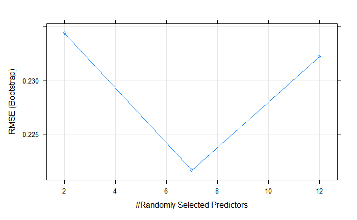

```r
plot(model)
```

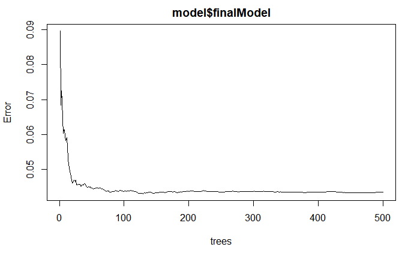

```r
plot(model$finalModel)
```

```r
# rpart.plot(model$finalModel,fallen.leaves = F)
```

```r
test.features = subset(testing, select=-c(MEDV))
test.target = subset(testing, select=MEDV)[,1]

predictions = predict(model, newdata = test.features)

# RMSE
sqrt(mean((test.target - predictions)^2))
```

```
[1] 0.1779694
```